# Analisi del Sonno

## Introduzione

Un buon sonno è uno degli elementi indispensabili per la salute fisica e mentale delle persone. Sorge quindi spontaneo chiedersi quali siano i parametri che influenzano maggiormente la qualità del sonno nella vita di tutti i giorni. L’analisi svolta riguarda dunque:

- Influenza di età e genere
- Influenza della caffeina
- Effetto dello stile di vita su durata e qualità
- Possibili cause dei risvegli notturni
- Influenza delle fasi sonno
- Conseguenze dell’ora di coricamento
- Modello basato sull’efficienza
- Conclusioni

## Dataset

[Sleep Efficiency Dataset](https://www.kaggle.com/datasets/equilibriumm/sleep-efficiency)

Il dataset utilizzato contiene informazioni relative agli schemi del sonno di circa 450 soggetti. I parametri forniti sono: ID, età, genere, ora di coricamento, ora di risveglio, durata del sonno in ore, **efficienza del sonno** (ovvero la percentuale di tempo effettivamente dormito), percentuali delle fasi del sonno (REM, profondo e leggero), numero di risvegli notturni, consumo di alcol (in bicchieri) e caffeina (in mg), stato di fumatore e frequenza di esercizio fisico settimanale.

L’efficienza verrà sfruttata come parametro per la qualità del sonno.

## Influenza di età e genere

*Genere* ed *età* influiscono sulla **durata** e sulla **qualità** del sonno?

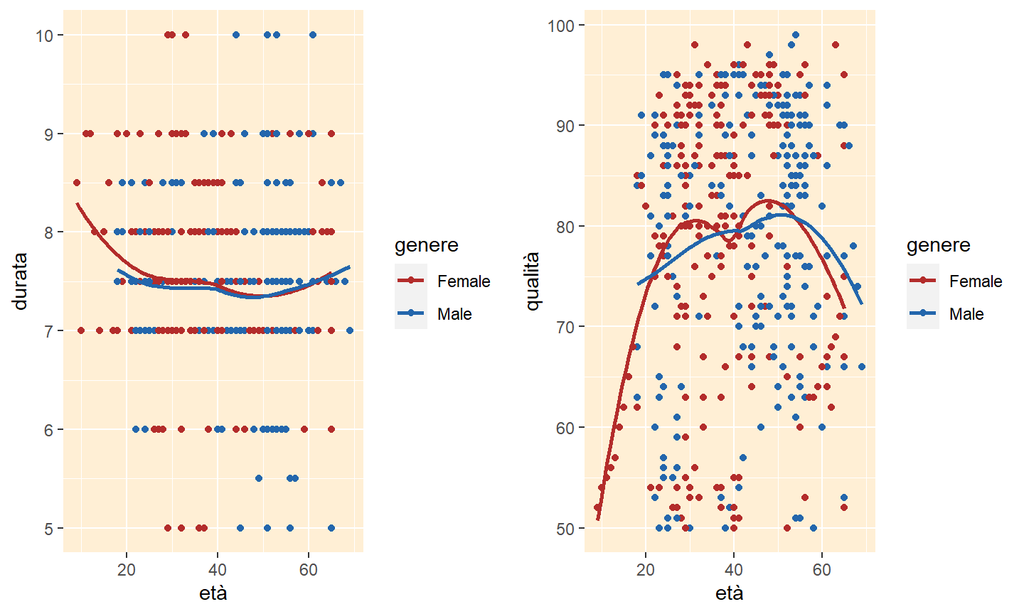

- Non sembrano esserci correlazioni significative con la **durata**.
- La **qualità** raggiunge un picco in corrispondenza dei 50-55 anni per gli uomini e dei 30 e 50 circa per le donne (con un lieve calo in corrispondenza dei 40 anni).

## Influenza della caffeina

La quantità di *caffeina* (mg) influenza **durata** e **qualità** del sonno?

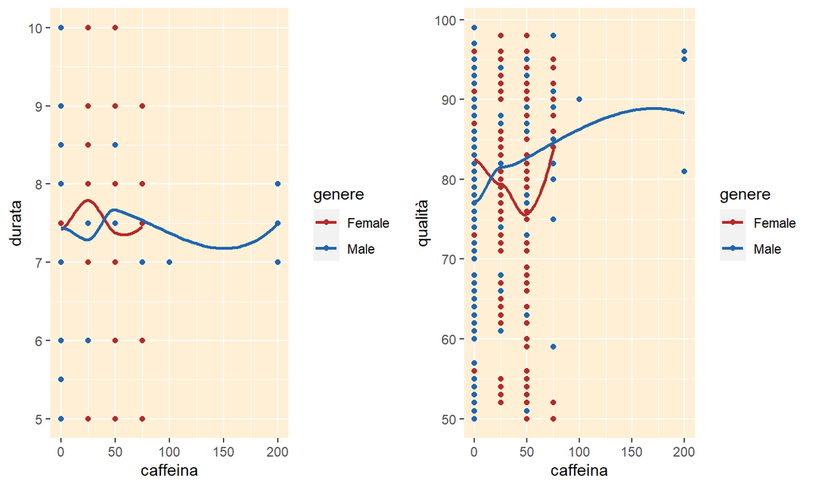

- La durata non sembra avere correlazioni con la caffeina
- La qualità è particolarmente ridotta per le donne che assumomo 50mg di caffeina, probabilmente è un risultato casuale

## Stile di vita e quantità di sonno

Consideriamo il numero di risvegli, l’assunzione di alcol, la frequenza di esercizio e se il soggetto è un fumatore o meno

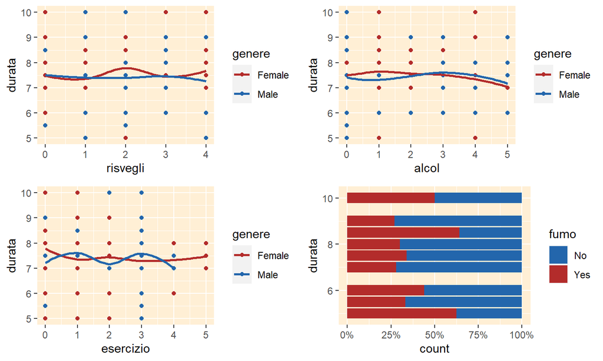

Non si notano particolari correlazioni, probabilmente perché la quantità è influenzata da orari di lavoro, scuola o altri

## Stile di vita e qualità del sonno

Consideriamo gli stessi parametri per la **qualità** del sonno

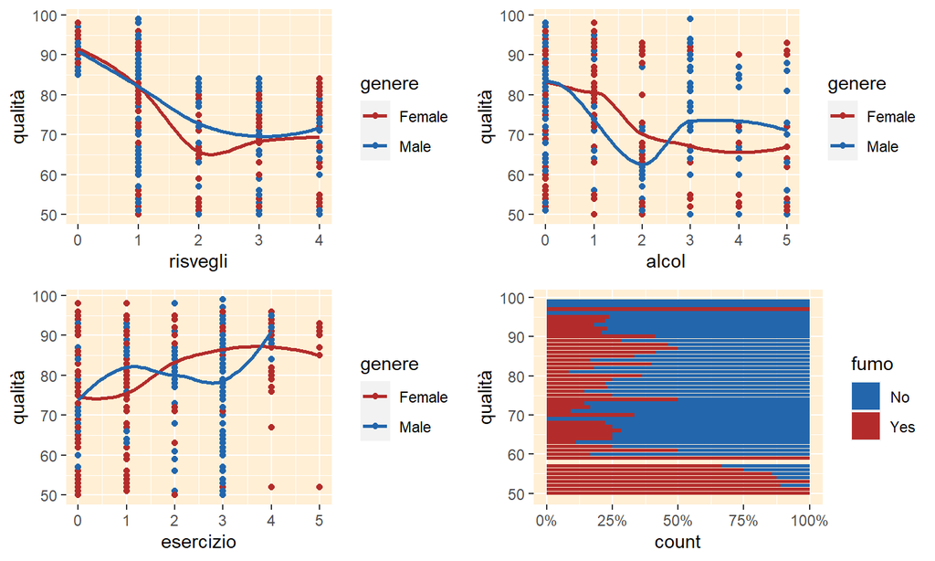

Una maggiore qualità del sonno è riscontrata in individui che:

- Hanno pochi risvegli notturni
- Non assumono alcol
- Svolgono spesso esercizio fisico
- Non fumano

## Cause dei risvegli

Lo stile di vita influenza anche il **numero di risvegli**? Consideriamo l’età, l’assunzione di alcol, la frequenza di esercizio e se il soggetto è un fumatore o meno

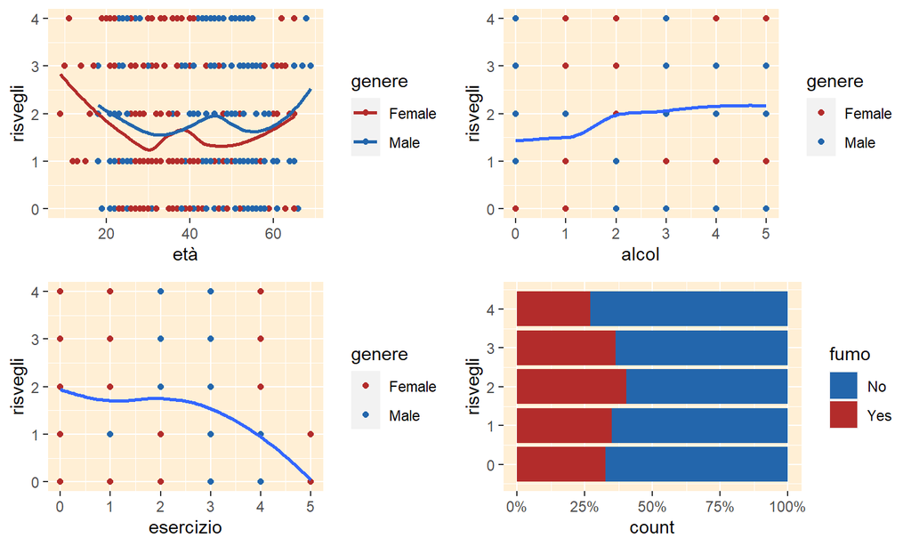

## Influenza delle fasi sonno

Il sonno è diviso in **REM** , sonno **profondo** e sonno **leggero**

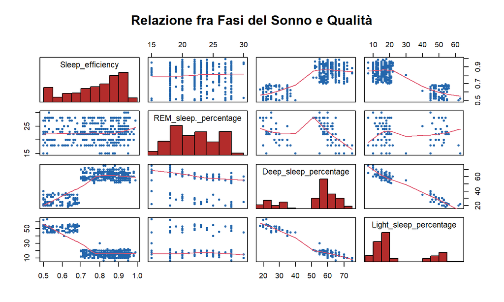

Si evidenzia che la **qualità** del sonno è:

- Indipendente dal sonno *REM*
- Direttamente proporzionale alla quantità di sonno *pesante*
- Inversamente proporzionale alla quantità di sonno *leggero*

Inoltre, la quantità di sonno pesante e leggero sono in relazione tra loro ma indipendenti dal sonno REM.

## Influenza dell’orario di coricamento

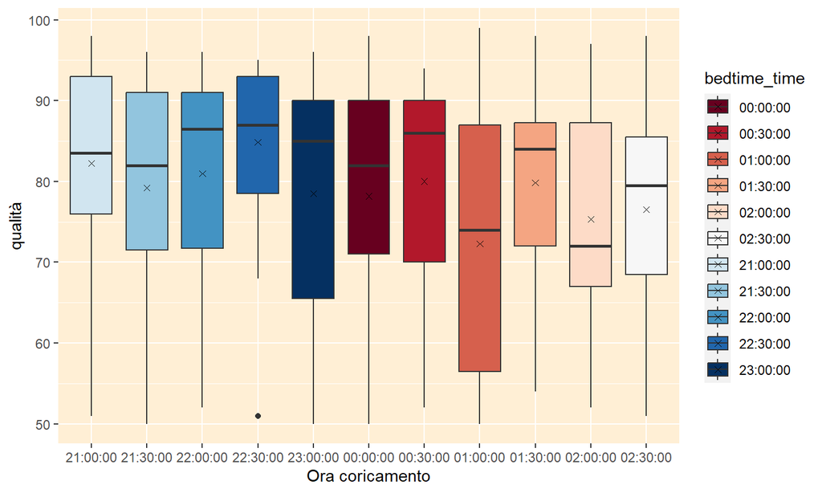

Non si evidenziano variazioni significative; indicativamente sembra:

- Preferibile andare a dormire fra le 22 e mezzanotte
- Sconsigliata la fascia oraria fra l’1 e le 3 di notte.

## Modello: Albero di Decisione

Il modello prende in considerazione l’**efficienza** del sonno divisa in intervalli tali da restituire valori compresi fra 5 e 9

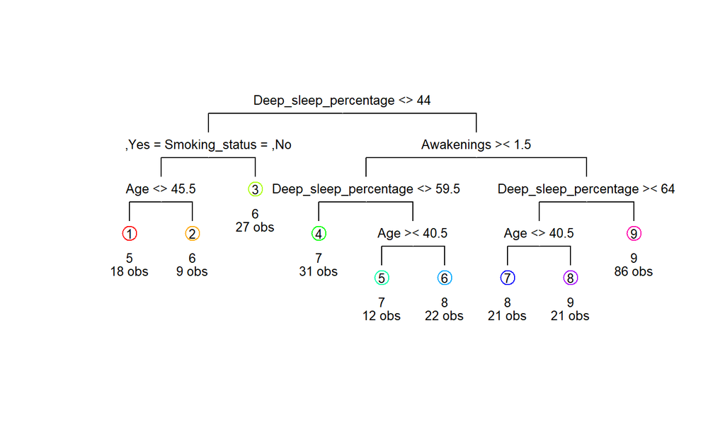

```
## Confusion Matrix and Statistics
##
##    dt_pred
##      5  6  7  8  9
##   5 18  6  0  0  0
##   6  1 17  0  0  0
##   7  0  0 13  3  4
##   8  0  0  7 10 19
##   9  0  0  0  5 38
##
## Overall Statistics
##
##                Accuracy : 0.6809
##                  95% CI : (0.5971, 0.7568)
##     No Information Rate : 0.4326
##     P-Value [Acc > NIR] : 2.402e-09
##
##                   Kappa : 0.5864
##
##  Mcnemar's Test P-Value : NA
##
## Statistics by Class:
##
##                      Class: 5 Class: 6 Class: 7 Class: 8 Class: 9
## Sensitivity            0.9474   0.7391   0.6500  0.55556   0.6230
## Specificity            0.9508   0.9915   0.9421  0.78862   0.9375
## Pos Pred Value         0.7500   0.9444   0.6500  0.27778   0.8837
## Neg Pred Value         0.9915   0.9512   0.9421  0.92381   0.7653
## Prevalence             0.1348   0.1631   0.1418  0.12766   0.4326
## Detection Rate         0.1277   0.1206   0.0922  0.07092   0.2695
## Detection Prevalence   0.1702   0.1277   0.1418  0.25532   0.3050
## Balanced Accuracy      0.9491   0.8653   0.7961  0.67209   0.7802
```